# Soap Berry - LTEM - Tatshenshini Alsek Park

Published

2023-02-23

# 1 Summary of Soap Berry LTEM protocol

## 1.1 Basic protocol

Areas rich in soapberries is located for permanent monitoring. In each area, 10 robust bushes are chosen, and two stems on each plant are chosen for sampling. The stems and bushes are marked with permanent tags so that they can be revisited each year.

There are three measures taken in this protocol.

- Berry count. The number of berries produced on the stem is recorded as an index of soapberry production.
- Stem diameter. The diameter (in millimeters) of the stem near its base is measured.
- Mean berry weight. A collection of 25-50 ripe red berries is obtained in August and weighed so the average wet weight of a single berry from each area is obtained.

If the tagged stem has died (or is damaged or the tag on the stem has “disappeared”), a new stem is chosen. This may be from a new bush or the same bush. If the stem has been browsed, then no count is conducted on this stem this year.

If the tagged bush has died (or the tags on all of the stems have “disappeared”), a new bush is selected for subsequent monitoring.

## 1.2 Cautions about the protocol.

### 1.2.1 Don’t use 0 to indicate a missing value.

If a branch is present but the berries cannot be counted (e.g. browsed), a standardized codes should be entered into the data base. The berry count should be entered as MISSING rather than as zero.

### 1.2.2 Codes for stem and bushes.

The Current field uses a plantxx-stemxx notation (e.g. plant1-stem1). If a bush dies and is replaced by a new bush, a different “plant” number should be used. Similarly if a stem is replaced on the same plant, use a different stem number (but linked to the same bush). If a new stem on new bush is used, both the plant (bush) and stem number should be new. Do NOT reuse bush numbers on different bushed; do not reuse stem numbers on the same bush.

## 1.3 Database structure

The relevant fields from the database are:

- Study Area Name. The name of the study area.
- Sample Station Label. The bush/stem label.
- Date. The date the data was collected. The Year is extracted from this date.
- Berry Count. The number of soap berries on this stem. If the stem is browsed (or damaged) a missing value should be entered here and not the value of 0.
- Stem Diameter. The diameter (mm) of the stem.
- Average Weight. The average weight of a sample of berries is collected. Notice that there is only ONE mean weight found per year and so this value  
  is replicated on every stem line of the sheet. The sample size used to determine the weight is in a separate column.

# 2 Reading and checking the data

The database was examined for all record pertaining to the Tatshenshini Alsek Park. The following surveys were found:

```
Surveys with the data
```

```
   SPI_PROJECT_ID SURVEY_ID          START_DATE         STUDY_AREA_NAME
32           5568     37818 2015-07-21 17:00:00 Tatshenshini Alsek Park
93           5568     47600 2019-07-31 17:00:00 Tatshenshini Alsek Park
```

The following data editing was performed

## 2.1 Variables names corrected for *R*

Variable names in *R* must start with a letter and contain letters or numbers or underscores. Blanks in variable names are not normally allowed, nor are special characters such as %. These are normally replaced by periods (“.”) in the variable name.

```
Original variable names in data frame
```

```
  [1] "PARENT_DESIGN_COMPONENT_ID"        "DESIGN_COMPONENT_ID"
  [3] "TAXONOMIC_UNIT_ID"                 "SURVEY_ID"
  [5] "SPI_PROJECT_ID"                    "STUDY_AREA_ID"
  [7] "STUDY_AREA_VISIT_ID"               "DESIGN_COMPONENT_VISIT_ID"
  [9] "VISIT_START_DATE"                  "VISIT_START_TIME"
 [11] "OBSERVATION_DATETIME"              "OBSERVATION_YEAR"
 [13] "OBSERVATION_MONTH"                 "OBSERVATION_DAY"
 [15] "VISIT_END_DATE"                    "VISIT_END_TIME"
 [17] "VISIT_TIME_SPAN"                   "VISIT_TIME_SPAN_UNIT_CODE"
 [19] "VISIT_TIME_SPAN_UNIT_NAME"         "VISIT_TIME_SPAN_UNIT_DEFN_URL"
 [21] "TRAP_EVENT_CODE"                   "TRAP_EVENT_NAME"
 [23] "TRAP_EVENT_DEFN_URL"               "TRAPS_SPRUNG"
 [25] "DISTANCE_COVERED_KM"               "NIGHTS_TRAPPED"
 [27] "SAMPLES"                           "VISIT_NOTE"
 [29] "NO_OBSERVATIONS_IND"               "TRIGGER_QUIET_PERIOD_SEC"
```

[output cut: 48 more lines]

```
Corrected variable names of data frame
```

```
  [1] "PARENT_DESIGN_COMPONENT_ID"        "DESIGN_COMPONENT_ID"
  [3] "TAXONOMIC_UNIT_ID"                 "SURVEY_ID"
  [5] "SPI_PROJECT_ID"                    "STUDY_AREA_ID"
  [7] "STUDY_AREA_VISIT_ID"               "DESIGN_COMPONENT_VISIT_ID"
  [9] "VISIT_START_DATE"                  "VISIT_START_TIME"
 [11] "OBSERVATION_DATETIME"              "OBSERVATION_YEAR"
 [13] "OBSERVATION_MONTH"                 "OBSERVATION_DAY"
 [15] "VISIT_END_DATE"                    "VISIT_END_TIME"
 [17] "VISIT_TIME_SPAN"                   "VISIT_TIME_SPAN_UNIT_CODE"
 [19] "VISIT_TIME_SPAN_UNIT_NAME"         "VISIT_TIME_SPAN_UNIT_DEFN_URL"
 [21] "TRAP_EVENT_CODE"                   "TRAP_EVENT_NAME"
 [23] "TRAP_EVENT_DEFN_URL"               "TRAPS_SPRUNG"
 [25] "DISTANCE_COVERED_KM"               "NIGHTS_TRAPPED"
 [27] "SAMPLES"                           "VISIT_NOTE"
 [29] "NO_OBSERVATIONS_IND"               "TRIGGER_QUIET_PERIOD_SEC"
```

[output cut: 48 more lines]

## 2.2 Check the number of records by year.

Check that the number of observations by year seems reasonable:

```
The number of records by year are
```

```
                         Year
STUDY_AREA_NAME           2015 2019
  Tatshenshini Alsek Park   20   20
```

## 2.3 Checking Study Area Name

The Study Area Name should be recorded consistently across years, otherwise it may indicate that different sites are being studies. The study area name is converted to Title Case.

The list of Study Area Names by year in the data is:

```
                         Year
STUDY_AREA_NAME           2015 2019
  Tatshenshini Alsek Park   20   20
```

## 2.4 Checking species code

The species code should be the same across the years of the project.

```
            Year
SPECIES_CODE 2015 2019
     SHEPCAN   20   20
```

## 2.5 Check the plant/bush and stem/branch numbers

The bush and stem numbers are also recorded. Each bush/plant should be followed for several years in a row, and the label for the bush should not be replicated if the bush is replaced by a new bush.

This needs to be check in the tables below. For example, ensure that a “bush” or “stem” is not measured for a few years, is not then measured, and then starts again – this may be an indication that the plant was replaced, but not relabeled (or a particular plant was not measured in a particular year)

```
         Year
BUSH      2015 2019
  plant1     2    2
  plant10    2    2
  plant2     2    2
  plant3     2    2
  plant4     2    2
  plant5     2    2
  plant6     2    2
  plant7     2    2
  plant8     2    2
  plant9     2    2
```

```
                 Year
STEM              2015 2019
  plant1-branch1     1    1
  plant1-branch2     1    1
  plant10-branch1    1    1
  plant10-branch2    1    1
  plant2-branch1     1    1
  plant2-branch2     1    1
  plant3-branch1     1    1
  plant3-branch2     1    1
  plant4-branch1     1    1
  plant4-branch2     1    1
  plant5-branch1     1    1
  plant5-branch2     1    1
  plant6-branch1     1    1
  plant6-branch2     1    1
  plant7-branch1     1    1
  plant7-branch2     1    1
  plant8-branch1     1    1
  plant8-branch2     1    1
  plant9-branch1     1    1
  plant9-branch2     1    1
```

## 2.6 Check the comments

The comments recorded should be reviewed in case these indicate problems with the data, For example, if the comment is “heavily browsed” make sure that the Berry.Count is recorded as NA and not as 0.

```
COMMENT
Wrong time of the year to monitor soapberry bushes. Beginning of August near the end had some dead leaves. Not yet ripe. Berries are more full and vibrant near water, looks like the creek flooded at some point. Within area, some bushes are booming, where others have absolutely no berries - this is b…
                                                                                                                                                                                                                                                                                                            …
                                                                                                                                                                                                                                                                                                            …
                                                                                                                                                                                                                                                                                                            …
```

# 3 Single Site Analysis

Date for the Tatshenshini Alsek Park are available from 2015 to 2019.

This design has multiple transects that are repeated measured over time with multiple plots measured on each transect that are also repeated measured over time. Please refer to the Fitting Trends with Complex Study Designs document in the CommonFile directory for information on fitting trends with complex study designs.

All analyses were done using the R (R Core Team, 2023) analysis system. All plots are also saved as separate *png files for inclusion into other reports.

## 3.1 Mean berry weight.

This measurement is taken at the site level and so there is one measurement available per site/year. Notice that this value is replicated multiple times in the database for each individual stem. These are NOT real replicated readings but only an artifact of the database so some care is needed to extract only a single value per individual stem on a site/year.

A simple linear regression is used to look for changes over time using the model (in standard notation)
$$\mathit{MBW} \sim \mathit{Year}$$
where

- $\mathit{MBW}$ is the mean berry weight and
- $\mathit{Year}$ is the calendar year over time.

This model can be fit using the *lm()* function in R.

```
Listing of SD of Mean.Berry weights by study area and year
```

```
          STUDY_AREA_NAME Year Mean.weight Mean.weight.sd
1 Tatshenshini Alsek Park 2015         NaN             NA
2 Tatshenshini Alsek Park 2019           1              0
```

```
*** Error - inadequate numbers of mean weight of berries
```

```
          STUDY_AREA_NAME Year Mean.weight Mean.weight.sd
1 Tatshenshini Alsek Park 2015         NaN             NA
2 Tatshenshini Alsek Park 2019           1              0
```

```
Analysis of Variance Table

Response: Mean.weight
          Df Sum Sq Mean Sq F value Pr(>F)
Residuals  0      0     NaN
```

```
Call:
lm(formula = Mean.weight ~ Year, data = berry.weight)

Residuals:
ALL 1 residuals are 0: no residual degrees of freedom!

Coefficients: (1 not defined because of singularities)
            Estimate Std. Error t value Pr(>|t|)
(Intercept)        1        NaN     NaN      NaN
Year              NA         NA      NA       NA

Residual standard error: NaN on 0 degrees of freedom
  (1 observation deleted due to missingness)
```

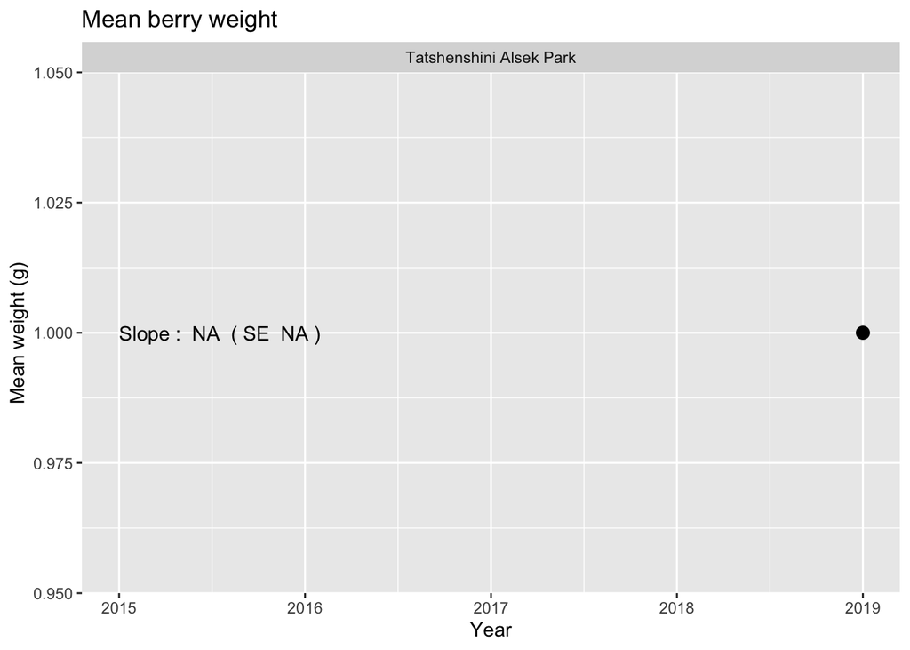

Figure 1: Trend in mean berry weight

[output not shown]

[output not shown]

It will also be possible to covariates such as mean winter temperature or degree days in the year to try and explain some of the variation over time using a multiple regression. With only 2 years of data available, this not sensible.

[output not shown]

If the number of berries used to compute the average is quite different over years, a weighted analysis (number of berries used in computing the mean) may be needed.

## 3.2 Stem Diameter.

This measurement is taken at the stem level and so there is one value per stem/bush/year. The same stem is repeatedly measured over time, but stems may leave the protocol (damaged or dead) or be added to the protocol (replacement stem) over time. All of the models below automatically will account for stems that are removed or added as long as each stem has a unique label within a site.

A linear mixed model will be used to look for changes over time to account for the repeated measurements over time of each branch on the same plant:
$$StemD \sim \mathit{Year} + \mathit{YearF}(R) + \mathit{BushF}(R)+ \mathit{StemF}(R)$$

where

- $StemD$ is the measured stem diameter,
- $\mathit{Year}$ is the term representing the trend over time;
- $\mathit{YearF(R)}$, $\mathit{BushF}(R)$, and $\mathit{StemF}(R)$ are the random effects of year-specific factors, bushes and stems respectively. These random effects are needed to account for the repeated measurement of the same stem (the $\mathit{StemF}(R)$) term; multiple stems measured from the same plant ($\mathit{BushF}(R)$) term; and year-specific factors (also known as process error, $\mathit{YearF(R)}$). The process error term is distinguished from the simple trend term $\mathit{Year}$.

For example, all of the stems on the same bush may have related diameters because they are all similar aged. Similarly, the repeated measurements on the same stem over time will be related.

This model is fit using the *lmer()* function in the lmerTest package (Kuznetsova, et al. 2016) and a summary is shown in Figure 2.

```
Type III Analysis of Variance Table with Satterthwaite's method
     Sum Sq Mean Sq NumDF      DenDF F value Pr(>F)
Year 437.21  437.21     1 0.00018234  0.3263 0.9992
```

```
                Estimate   Std. Error           df    t value  Pr(>|t|)
(Intercept) -59189.83785 103731.76065 0.0001823414 -0.5706048 0.9991913
Year            29.37642     51.42871 0.0001823413  0.5712066 0.9991911
```

```
          STUDY_AREA_NAME Year  mean.stem
1 Tatshenshini Alsek Park 2015   4.394737
2 Tatshenshini Alsek Park 2019 121.150000
```

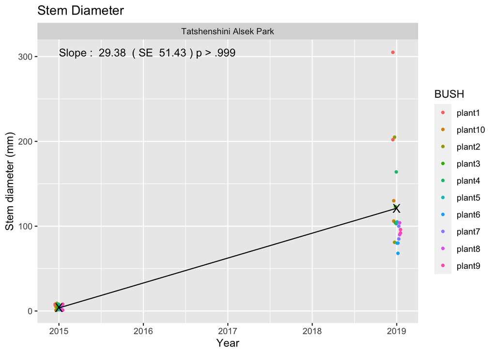

Figure 2: Trend in mean stem diameter. Points are jittered to reduce overplotting. The X indicate the observed mean of the data points in each year and deviations of the X from the trend line would represent (approximately) process error.

Table 1: Estimated variance components for stem diameter

| Source | SD |
| --- | --- |
| STEM | 0.000 |
| BUSH | 19.514 |
| Year | 145.225 |
| Residual | 36.606 |

One of the outputs from this analysis is the relative size of the standard deviations in the points due to year-specific factor, bushes, stems within bushes, and residual (unknown) sources (Table 1).

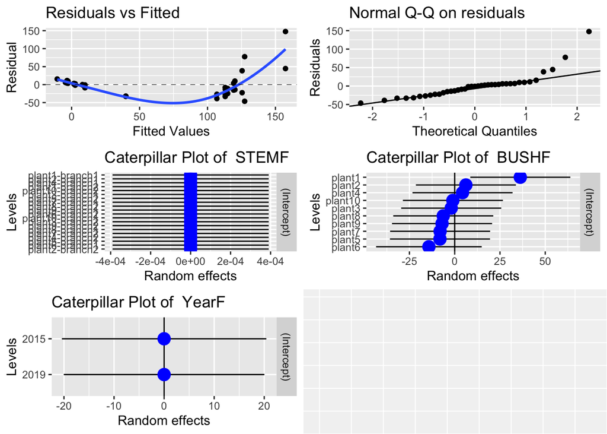

Figure 3: Model fit diagnostic plots from trend in stem diameter

As with the analysis of mean berry weight, covariates can also be added to the model to explain some of the year-specific effects.

[output not shown]

[output not shown]

[output not shown]

[output not shown]

## 3.3 Berry Count.

A linear mixed model will be used to look for changes over time in the mean berry count to account for the repeated measurements over time of each branch on the same plant:
$$log(BerryCount+0.5) \sim \mathit{Year} + \mathit{YearF(R)} + \mathit{BushF}(R)+ Stem(R)$$

where

- $BerryCount$ is the measured berry count on a stem,
- $\mathit{Year}$ is the trend;
- $\mathit{YearF}(R)$, $\mathit{BushF}(R)$, and $\mathit{StemF}(R)$ are the random effects of year-specific factors, bushes and stems respectively. These random effects are needed to account for the repeated measurement of the same stem (the $\mathit{StemF}(R)$) term; multiple stems measured from the same plant ($\mathit{BushF}(R)$) term; and year-specific factors (also known as process error, $\mathit{YearF(R)}$). The process error term is distinguished from the simple trend term $\mathit{Year}$.

This model is fit using the *lmer()* function in the lmerTest package (Kuznetsova, et al. 2016) and a summary is shown in Figure 4.

```
Type III Analysis of Variance Table with Satterthwaite's method
     Sum Sq Mean Sq NumDF      DenDF F value Pr(>F)
Year 1.5668  1.5668     1 1.1398e-06  0.6771      1
```

```
                Estimate  Std. Error           df    t value  Pr(>|t|)
(Intercept) -671.7829677 821.1000041 1.139797e-06 -0.8181500 0.9999916
Year           0.3349669   0.4070895 1.139797e-06  0.8228335 0.9999916
```

With 2 years of data, the estimated slope on the logarithmic scale is 0.335 (SE 0.407) g/year (p > .999).

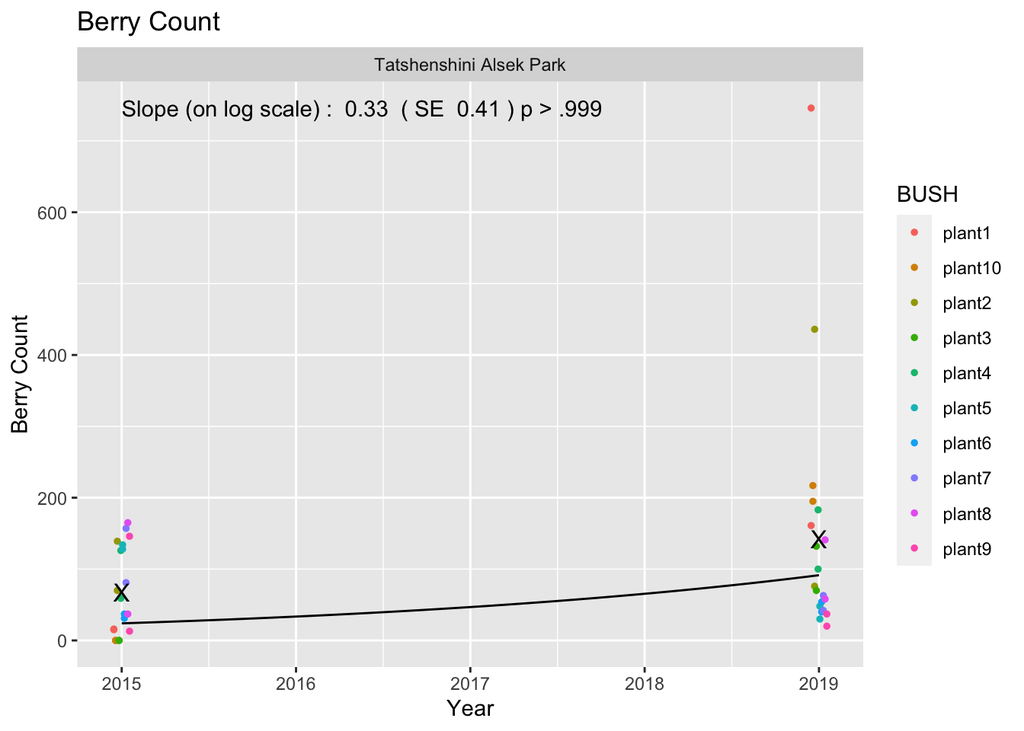

Table 2: Estimated variance components for berry counts

| Source | SD |
| --- | --- |
| STEM | 0.000 |
| BUSH | 0.640 |
| Year | 1.100 |
| Residual | 1.521 |

One of the outputs from this analysis is the relative size of the standard deviations in the points due to year-specific factor, bushes, stems within bushes, and residual (unknown) sources (Table 2).

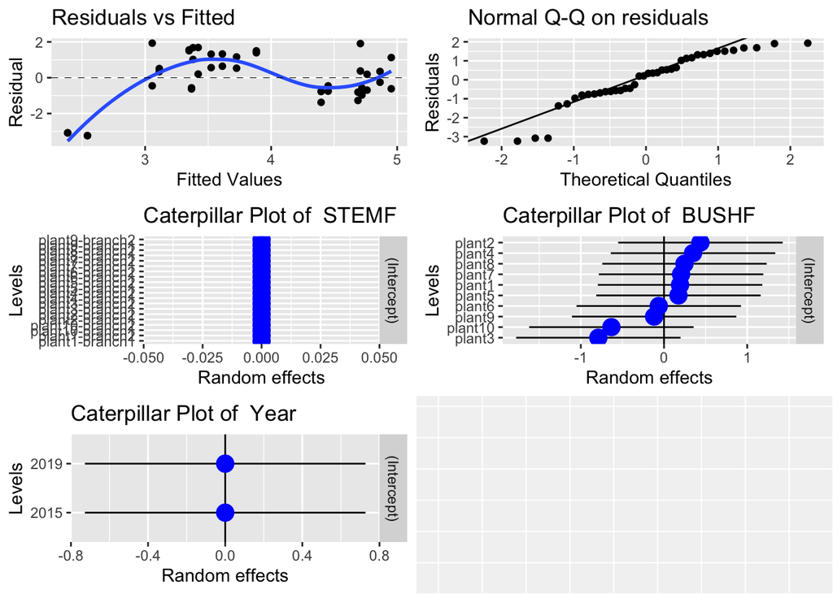

Figure 5: Model fit diagnostic plots from trend in berry counts

As with the analysis of mean berry weight, covariates can also be added to the model to explain some of the year-specific effects.

Whenever an analysis of a trend over time is conducted, the analysis will have to test and adjust for autocorrelation in the year-specific effect. This usually isn’t a problem unless there are 10+ years of data. Autocorrelation usually isn’t a problem (and likely cannot be detected) unless you have 10+ years of data. The test for autocorrelation commonly used is the Durbin-Watson test and we find p is Not avail for the test of no autocorrelation.

# 4 Power analysis

A power/sample size analysis was conducted to determine the number of years of sampling needed to detect changes over time. The steps in the power/sample size analysis are:

- Compute a single number summarizing the response at this site in each year. The mean berry weight is already a single number per year. The mean stem diameter and mean berry count will be computed as averages of averages over the various sampling units to give each bush/branch an equal weight.
- Analyze the log(mean response) using a simple linear regression. This will give an estimate of the combined year-specific and sampling variation around regression line (overall sd).
- Use the overall SD to estimate power and sample size requirements.

Here are the overall means for each year for each response:

```
          STUDY_AREA_NAME Year Mean.response      Response
1 Tatshenshini Alsek Park 2015           NaN  Berry weight
2 Tatshenshini Alsek Park 2019         1.000  Berry weight
3 Tatshenshini Alsek Park 2015         4.425 Stem Diameter
4 Tatshenshini Alsek Park 2019       121.150 Stem Diameter
5 Tatshenshini Alsek Park 2015        67.700   Berry Count
6 Tatshenshini Alsek Park 2019       142.450   Berry Count
```

The above data needs to be checked if there are any suspicious values.

We use the *lm()* function to fit linear regression over time on the log(scale) and obtain the combined year-specific effect (process error) plus sampling variation standard deviation (Table 3).

Table 3: Estimated residual (process + sampling) standard deviation

[output not shown]

[output not shown]

The proportional yearly slope indicates the effect size of interest. For example, a value of .02 would indicated a 2% change/year in the mean response.

# 5 Summary

At the moment, with short time series, the estimated power may not be fully reliable because of uncertainty in estimating the residual standard deviation, but is a start to understanding how many years would be needed to detect proportion changes over time.

# 6 References

Kuznetsova A, Brockhoff PB, Christensen RHB (2017). lmerTest Package: Tests in Linear Mixed Effects Models. Journal of Statistical Software, 82, 1-26. doi:10.18637/jss.v082.i13

R Core Team (2023). R: A language and environment for statistical computing. R Foundation for Statistical Computing, Vienna, Austria. https://www.R-project.org/.